# R Notebook

Call Libraries

```r
library(tidyverse)
library(janitor)
library(here)
library(lubridate)
```

**Labour_Productivity-OECD_Countries**

Read data

```r
gdp_phw <- read_csv(here("raw_data/OECD_GDP_per_Hour_Worked_JHios.csv")) %>%
  clean_names()
glimpse(gdp_phw)
```

```
Rows: 3,814
Columns: 8
$ location   <chr> "AUS", "AUS", "AUS", "AUS", "AUS", "AUS", "AUS", "AUS", "AUS", "AUS", "AUS", "AUS", "AUS", "AUS", "AUS", ~
$ indicator  <chr> "GDPHRWKD", "GDPHRWKD", "GDPHRWKD", "GDPHRWKD", "GDPHRWKD", "GDPHRWKD", "GDPHRWKD", "GDPHRWKD", "GDPHRWKD~
$ subject    <chr> "TOT", "TOT", "TOT", "TOT", "TOT", "TOT", "TOT", "TOT", "TOT", "TOT", "TOT", "TOT", "TOT", "TOT", "TOT", ~
$ measure    <chr> "USD", "USD", "USD", "USD", "USD", "USD", "USD", "USD", "USD", "USD", "USD", "USD", "USD", "USD", "USD", ~
$ frequency  <chr> "A", "A", "A", "A", "A", "A", "A", "A", "A", "A", "A", "A", "A", "A", "A", "A", "A", "A", "A", "A", "A", ~
$ time       <dbl> 1970, 1971, 1972, 1973, 1974, 1975, 1976, 1977, 1978, 1979, 1980, 1981, 1982, 1983, 1984, 1985, 1986, 198~
$ value      <dbl> 26.84966, 27.51984, 28.12699, 28.70706, 28.24612, 29.29258, 29.78026, 29.74578, 31.00299, 31.16227, 31.51~
$ flag_codes <chr> NA, NA, NA, NA, NA, NA, NA, NA, NA, NA, NA, NA, NA, NA, NA, NA, NA, NA, NA, NA, NA, NA, NA, NA, NA, NA, N~
```

Change time in datetime format

```r
gdp_phw <- gdp_phw %>%
  mutate(time = make_datetime(time))
```

Check for NA values

```r
gdp_phw %>%
  summarise(across(.cols = everything(),
                   .fns = ~sum(is.na(.x))))
```

| location | indicator | subject | measure | frequency | time | value | flag_codes |
| --- | --- | --- | --- | --- | --- | --- | --- |
| 0 | 0 | 0 | 0 | 0 | 0 | 0 | 3760 |

View data

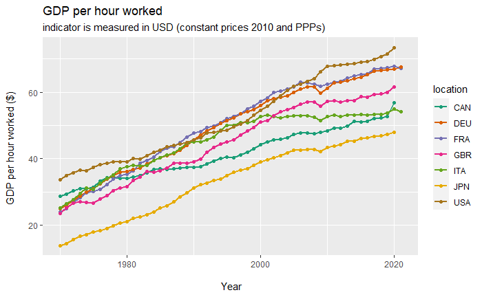

```r
gdp_phw %>%
  select(-c(indicator, subject, frequency, flag_codes)) %>%
  filter(
    location %in% c("CAN", "FRA", "DEU", "ITA", "JPN", "USA", "GBR"),
    measure == "USD") %>%
  ggplot() +
  aes(x = time, y = value, colour = location) +
  geom_line(size = 0.75) +
  geom_point(size = 1.5) +
  scale_colour_brewer(palette = "Dark2") +
  ggtitle(
    "GDP per hour worked",
    subtitle =  "indicator is measured in USD (constant prices 2010 and PPPs)"
  ) +
  labs(
    x = "\n Year",
    y = "GDP per hour worked ($) \n"
  )
```

```r
NA
```

G-7 GDP per hour worked data

```r
gdp_phw_g7 <- gdp_phw %>%
  filter(
    location %in% c("CAN", "FRA", "DEU", "ITA", "JPN", "USA", "GBR"),
    measure == "USD"
  ) %>%
  select(-c(indicator, frequency, measure, subject, flag_codes)) %>%
  rename(gdp_phw_usd = value)
```

OECD Investment by Asset

Read data

```r
inv_asset <- read_csv(here("raw_data/OECD_Investment_by_Asset_JHios.csv")) %>%
  clean_names()
glimpse(inv_asset)
```

```
Rows: 8,113
Columns: 8
$ location   <chr> "NZL", "NZL", "NZL", "NZL", "NZL", "NZL", "NZL", "NZL", "NZL", "NZL", "NZL", "NZL", "NZL", "NZL", "NZL", ~
$ indicator  <chr> "GFCFASSET", "GFCFASSET", "GFCFASSET", "GFCFASSET", "GFCFASSET", "GFCFASSET", "GFCFASSET", "GFCFASSET", "~
$ subject    <chr> "OTHMACHINEQT", "OTHMACHINEQT", "OTHMACHINEQT", "OTHMACHINEQT", "OTHMACHINEQT", "OTHMACHINEQT", "OTHMACHI~
$ measure    <chr> "PC_GFCF", "PC_GFCF", "PC_GFCF", "PC_GFCF", "PC_GFCF", "PC_GFCF", "PC_GFCF", "PC_GFCF", "PC_GFCF", "PC_GF~
$ frequency  <chr> "A", "A", "A", "A", "A", "A", "A", "A", "A", "A", "A", "A", "A", "A", "A", "A", "A", "A", "A", "A", "A", ~
$ time       <dbl> 1971, 1972, 1973, 1974, 1975, 1976, 1977, 1978, 1979, 1980, 1981, 1982, 1983, 1984, 1985, 1986, 1987, 198~
$ value      <dbl> 2.344740, 2.342159, 2.228047, 2.629709, 2.733353, 3.194038, 4.008384, 4.309313, 5.015816, 5.423534, 6.169~
$ flag_codes <chr> NA, NA, NA, NA, NA, NA, NA, NA, NA, NA, NA, NA, NA, NA, NA, NA, NA, NA, NA, NA, NA, NA, NA, NA, NA, NA, N~
```

Change time in datetime format

```r
inv_asset <- inv_asset %>%
  mutate(time = make_datetime(time))
```

Check for NA’s

```r
inv_asset %>%
  summarise(across(.cols = everything(),
                   .fns = ~sum(is.na(.x))))
```

| location | indicator | subject | measure | frequency | time | value | flag_codes |
| --- | --- | --- | --- | --- | --- | --- | --- |
| 0 | 0 | 0 | 0 | 0 | 0 | 0 | 7307 |

```r
inv_asset %>%
  # distinct(LOCATION)
  # distinct(INDICATOR) # GFCFASSET
  distinct(subject) # OTHMACHINEQT, CULTASSET, OTHBUILDING, FIXASSET, TRANSPEQT, DWELLING
```

| subject |
| --- |
| OTHMACHINEQT |
| CULTASSET |
| OTHBUILDING |
| FIXASSET |
| TRANSPEQT |
| DWELLING |

```r
  # distinct(MEASURE) # PC_GFCF
  # distinct(FREQUENCY) #A
  # distinct(`Flag Codes`) # NA, E, B
```

OTHMACHINEQT: Information and Communication Technology (ICT) equipment (computer software and databases, telecommunications equipment and computer hardware)

CULTASSET: cultivated biological resources (managed forests, livestock raised for milk production, etc.)

OTHBUILDING: other buildings and structures (roads, bridges, airfields, dams, etc.)

FIXASSET: intellectual property products (such as R&D, mineral exploration, software and databases, and literary and artistic originals, etc.)

TRANSPEQT: transport equipment (ships, trains, aircraft, etc.)

DWELLING: dwellings (excluding land)

G-7 Cross country investment by Asset (% GFCF)

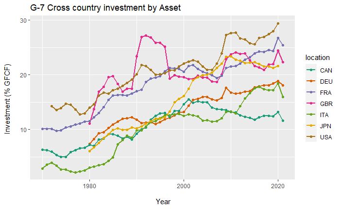

```r
inv_asset %>%
  select(-c(indicator, frequency, flag_codes)) %>%
  filter(
    location %in% c("CAN", "FRA", "DEU", "ITA", "JPN", "USA", "GBR"),
    # subject== "OTHMACHINEQT",
    # subject == "CULTASSET",
    # subject == "OTHBUILDING",
    subject == "FIXASSET",
    # subject == "TRANSPEQT",
    # subject == "DWELLING"
  ) %>%
  ggplot() +
  aes(x = time, y = value, colour = location) +
  geom_line(size = 0.75) +
  geom_point(size = 1.5) +
  scale_colour_brewer(palette = "Dark2") +
  ggtitle("G-7 Cross country investment by Asset") +
  labs(
    x = "\n Year",
    y = "Investment (% GFCF) \n"
  )
```

OECD Investment GFCF

Read data

```r
gfcf <- read_csv(here("raw_data/OECD_Investment_GFCF_JHios.csv")) %>%
  clean_names()
glimpse(gfcf)
```

```
Rows: 23,956
Columns: 8
$ location   <chr> "AUS", "AUS", "AUS", "AUS", "AUS", "AUS", "AUS", "AUS", "AUS", "AUS", "AUS", "AUS", "AUS", "AUS", "AUS", ~
$ indicator  <chr> "GFCF", "GFCF", "GFCF", "GFCF", "GFCF", "GFCF", "GFCF", "GFCF", "GFCF", "GFCF", "GFCF", "GFCF", "GFCF", "~
$ subject    <chr> "TOT", "TOT", "TOT", "TOT", "TOT", "TOT", "TOT", "TOT", "TOT", "TOT", "TOT", "TOT", "TOT", "TOT", "TOT", ~
$ measure    <chr> "AGRWTH", "AGRWTH", "AGRWTH", "AGRWTH", "AGRWTH", "AGRWTH", "AGRWTH", "AGRWTH", "AGRWTH", "AGRWTH", "AGRW~
$ frequency  <chr> "A", "A", "A", "A", "A", "A", "A", "A", "A", "A", "A", "A", "A", "A", "A", "A", "A", "A", "A", "A", "A", ~
$ time       <chr> "1960", "1961", "1962", "1963", "1964", "1965", "1966", "1967", "1968", "1969", "1970", "1971", "1972", "~
$ value      <dbl> 5.671711, 1.778081, 6.252030, 9.366150, 7.483513, 8.132420, 5.097216, 7.374136, 6.391864, 3.280286, 3.221~
$ flag_codes <chr> NA, NA, NA, NA, NA, NA, NA, NA, NA, NA, NA, NA, NA, NA, NA, NA, NA, NA, NA, NA, NA, NA, NA, NA, NA, NA, N~
```

Change time in datetime format

```r
gfcf <- gfcf %>%
  mutate(time = make_datetime(time))
```

Check for NA’s

```r
gfcf %>%
  summarise(across(.cols = everything(),
                   .fns = ~sum(is.na(.x))))
```

| location | indicator | subject | measure | frequency | time | value | flag_codes |
| --- | --- | --- | --- | --- | --- | --- | --- |
| 0 | 0 | 0 | 0 | 0 | 18811 | 0 | 16402 |

```r
gfcf %>%
  # distinct(LOCATION)
  # distinct(INDICATOR) # GFCF
  # distinct(SUBJECT) # TOT
  distinct(measure) # AGRWTH, MLN_USD, QGRWTH
```

| measure |
| --- |
| AGRWTH |
| MLN_USD |
| QGRWTH |

```r
  # distinct(FREQUENCY) #A, Q
  # distinct(`Flag Codes`) # NA, E, P, B, D
```

AGRWTH: Annual growth (%) MLN_USD: Million US Dollars QGRWTH: Quarterly growth rate (%)

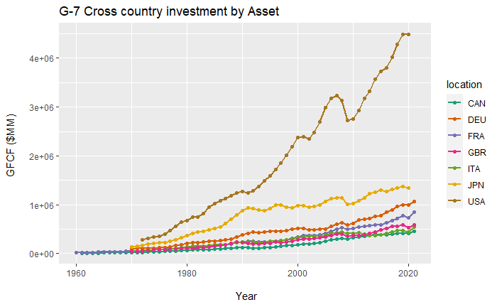

```r
gfcf %>%
  select(-c(indicator, frequency, subject, flag_codes)) %>%
  filter(
    location %in% c("CAN", "FRA", "DEU", "ITA", "JPN", "USA", "GBR"),
    measure == "MLN_USD"
    ) %>%
  ggplot() +
  aes(x = time, y = value, color = location) +
  geom_line(size = 0.75) +
  geom_point(size = 1.5) +
  scale_colour_brewer(palette = "Dark2") +
  ggtitle("G-7 Cross country investment by Asset") +
  labs(
    x = "\n Year",
    y = "GFCF ($MM) \n"
  )
```

Join investment by asset with GFCF data

```r
gfcf_light <- gfcf %>%
  filter(measure == "MLN_USD") %>%
  select(location, time, value) %>%
  rename(gfcf = value)

inv_asset_usd <- inv_asset %>%
  arrange(location, subject, time) %>%
  left_join(gfcf_light, by = c("location", "time")) %>%
  mutate(
    value_mil_usd = value * gfcf / 100
  )
```

G-7 Cross country investment by Asset (million USD)

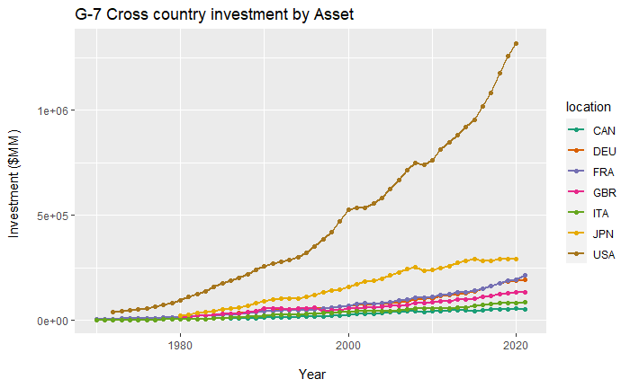

```r
inv_asset_usd %>%
  select(-c(indicator, frequency, measure, flag_codes, value, gfcf)) %>%
  filter(
    location %in% c("CAN", "FRA", "DEU", "ITA", "JPN", "USA", "GBR"),
    # subject == "OTHMACHINEQT",
    # subject == "CULTASSET",
    # subject == "OTHBUILDING",
    subject == "FIXASSET",
    # subject == "TRANSPEQT",
    # subject == "DWELLING"
  ) %>%
  ggplot() +
  aes(x = time, y = value_mil_usd, colour = location) +
  geom_line(size = 0.75) +
  geom_point(size = 1.5) +
  scale_colour_brewer(palette = "Dark2") +
  ggtitle("G-7 Cross country investment by Asset") +
  labs(
    x = "\n Year",
    y = "Investment ($MM) \n"
  )
```

OTHMACHINEQT: Information and Communication Technology (ICT) equipment (computer software and databases, telecommunications equipment and computer hardware)

CULTASSET: cultivated biological resources (managed forests, livestock raised for milk production, etc.)

OTHBUILDING: other buildings and structures (roads, bridges, airfields, dams, etc.)

FIXASSET: intellectual property products (such as R&D, mineral exploration, software and databases, and literary and artistic originals, etc.)

TRANSPEQT: transport equipment (ships, trains, aircraft, etc.)

DWELLING: dwellings (excluding land)

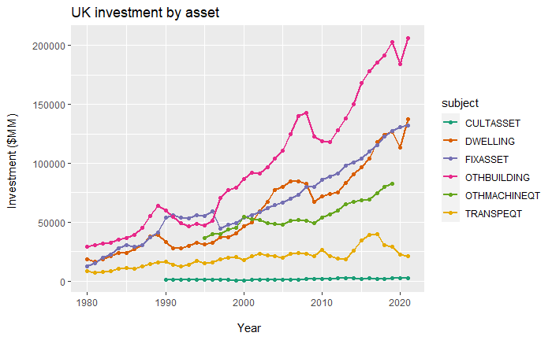

```r
inv_asset_usd %>%
  select(-c(indicator, frequency, measure, flag_codes)) %>%
  filter(location %in% c("GBR")) %>%
  ggplot() +
  aes(x = time, y = value_mil_usd, colour = subject) +
  geom_line(size = 0.75) +
  geom_point(size = 1.5) +
  scale_colour_brewer(palette = "Dark2") +
  # scale_colour_manual(values = cbb_palette) +
  ggtitle("UK investment by asset") +
  labs(
    x = "\n Year",
    y = "Investment ($MM) \n"
  )
```

G-7 investment by Asset (million USD)

```r
inv_asset_g7 <- inv_asset %>%
  filter(
    location %in% c("CAN", "FRA", "DEU", "ITA", "JPN", "USA", "GBR")
    ) %>%
  select(-c(indicator, frequency, measure, flag_codes)) %>%
  pivot_wider(names_from = subject, values_from = value) %>%
  rename(
    ict = OTHMACHINEQT,
    cultasset = CULTASSET,
    infrastuct = OTHBUILDING,
    intelprop = FIXASSET,
    transpeqt = TRANSPEQT,
    dwelling = DWELLING
  ) %>%
  left_join(gfcf_light, by = c("location", "time")) %>%
  mutate(
    ict_mil_usd = ict * gfcf / 100,
    cultasset_mil_usd = cultasset * gfcf / 100,
    infrastuct_mil_usd = infrastuct * gfcf / 100,
    intelprop_mil_usd = intelprop * gfcf / 100,
    transpeqt_mil_usd = transpeqt * gfcf / 100,
    dwelling_mil_usd = dwelling * gfcf / 100
  ) %>%
  select(-gfcf, -ict, -cultasset, -infrastuct, -intelprop, -transpeqt, -dwelling) %>%
  arrange(location, time)
```

OECD Education Spending Expenditure

Read data

```r
edu_exp <- read_csv(here("raw_data/OECD_Public_Spending_on_Education_JHios.csv")) %>%
  clean_names()
glimpse(edu_exp)
```

```
Rows: 1,620
Columns: 8
$ location   <chr> "AUS", "AUS", "AUS", "AUS", "AUS", "AUS", "AUS", "AUS", "AUS", "AUS", "AUS", "AUS", "AUS", "AUT", "AUT", ~
$ indicator  <chr> "EDUPUBEXP", "EDUPUBEXP", "EDUPUBEXP", "EDUPUBEXP", "EDUPUBEXP", "EDUPUBEXP", "EDUPUBEXP", "EDUPUBEXP", "~
$ subject    <chr> "TRY", "TRY", "TRY", "TRY", "TRY", "TRY", "TRY", "TRY", "TRY", "TRY", "TRY", "TRY", "TRY", "TRY", "TRY", ~
$ measure    <chr> "PC_GDP", "PC_GDP", "PC_GDP", "PC_GDP", "PC_GDP", "PC_GDP", "PC_GDP", "PC_GDP", "PC_GDP", "PC_GDP", "PC_G~
$ frequency  <chr> "A", "A", "A", "A", "A", "A", "A", "A", "A", "A", "A", "A", "A", "A", "A", "A", "A", "A", "A", "A", "A", ~
$ time       <dbl> 2000, 2005, 2008, 2009, 2010, 2011, 2012, 2013, 2014, 2015, 2016, 2017, 2018, 2012, 2013, 2014, 2015, 201~
$ value      <dbl> 0.7460824, 0.6911921, 0.6902357, 0.7358844, 0.7797844, 0.7440488, 0.7194145, 0.7188712, 0.7170264, 0.7682~
$ flag_codes <lgl> NA, NA, NA, NA, NA, NA, NA, NA, NA, NA, NA, NA, NA, NA, NA, NA, NA, NA, NA, NA, NA, NA, NA, NA, NA, NA, N~
```

Change time in datetime format

```r
edu_exp <- edu_exp %>%
  mutate(time = make_datetime(time))
```

Check for NA’s

```r
edu_exp %>%
  summarise(across(.cols = everything(),
                   .fns = ~sum(is.na(.x))))
```

| location | indicator | subject | measure | frequency | time | value | flag_codes |
| --- | --- | --- | --- | --- | --- | --- | --- |
| 0 | 0 | 0 | 0 | 0 | 0 | 0 | 1620 |

G-7 countries education expenditure (% GDP) TRY : TeRtiarY PRY_NTRY: PRimarY to post-secondary Non-TeRtiarY PRY_TRY: PRimarY to TeRtiarY